# Lab 6

Patrick Pelegri-O’Day

11/1/2021

## Example of a rank-based test

We’ll make our own samples, using a pseudorandom generator.

```r
set.seed(1414) # psuedorandom generator - everyone who uses this code will have the same random sample
gp_1 <- sample.int(20, size = 15, replace = TRUE) # gives a range from 0 to 20, sample size = 15, once the value of an observation is used, that number gets put back in the possible pool of numbers that can be chosen from, so a number can be used multiple times

set.seed(1424)
gp_2 <- sample.int(30, size = 15, replace = TRUE)
```

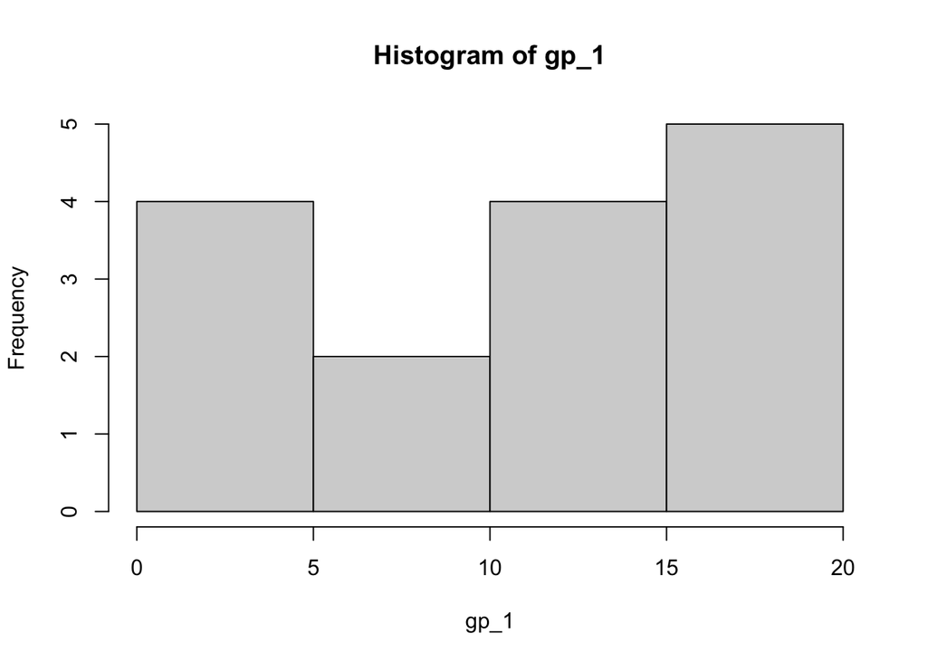

```r
hist(gp_1)
```

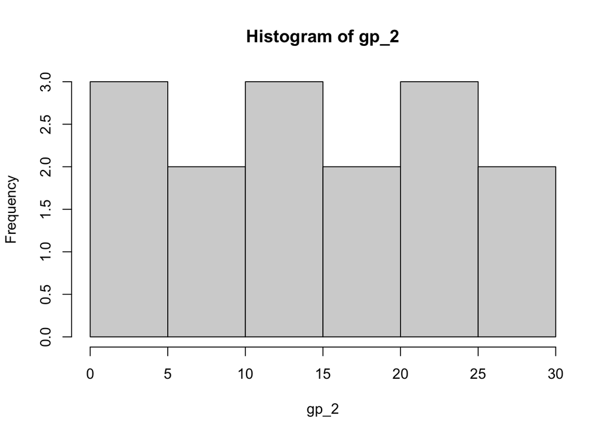

```r
hist(gp_2)
```

Try a t-test

```r
t.test(gp_1, gp_2)
```

```
##
##  Welch Two Sample t-test
##
## data:  gp_1 and gp_2
## t = -1.3241, df = 23.545, p-value = 0.1982
## alternative hypothesis: true difference in means is not equal to 0
## 95 percent confidence interval:
##  -9.558315  2.091648
## sample estimates:
## mean of x mean of y
##  11.40000  15.13333
```

This p-value means that if these two random samples were drawn from populations with the same mean, there is a probability of 19.8% that we would take two random samples that have means at least as different as the sample means we found by random chance.

As a result we would retain (fail to reject) the null hypothesis. (People get weirdly upset if you say “accept” the null.) There is no significant difference in means between group 1 and group 2.

Now let’s compare this outcome to a rank-based test

## Mann Whitney U unpaired rank-based test

```r
mwu <- wilcox.test(gp_1, gp_2)
mwu
```

```
##
##  Wilcoxon rank sum test with continuity correction
##
## data:  gp_1 and gp_2
## W = 86, p-value = 0.28
## alternative hypothesis: true location shift is not equal to 0
```

If these samples were drawn from populations with the same ranks (medians), the probability of finding two samples with ranks as least as different as those in our samples is 28%.

There is no significatn different in ranks between group 1 and group 2.

Median scores for group 1 (M = 14) and group 2 (M = 12) did not differ significantly (Mann Whitney U test: U(df) = 86, p = 0.28)

**Important note** when you decide what is an appropriate test to use, you apply that consistently. e.g. don’t talk about medians at one point then use a t-test (which compares means)

## Linear regression

Simple linear regression (single dependent variable, a single independent variable)

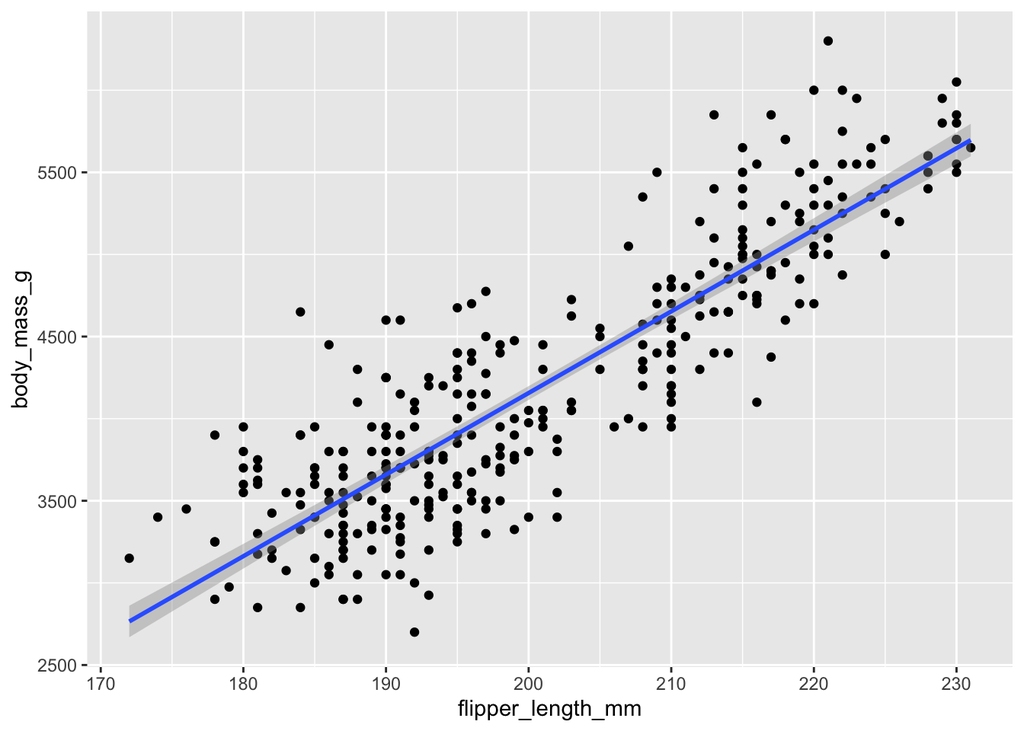

```r
# Make an exploratory plot of penguin body mass (y-axis) versus flipper length (x-axis)

ggplot(data = penguins, aes(x = flipper_length_mm, y = body_mass_g)) +
  geom_point() +
  geom_smooth(method = "lm") # add linear trend line - dangerous! calculated using ordinary least squares
```

Find a linear regression model using ordinary least squares describing the relationship between flipper length and body mass for these penguins.

3 pieces:

- What type of model?
- What is the relationship to model (DV - IV(s))
- Where is the data that’s used to create this model?

```r
penguin_lm <- lm(body_mass_g ~ flipper_length_mm, data = penguins)

penguin_lm
```

```
##
## Call:
## lm(formula = body_mass_g ~ flipper_length_mm, data = penguins)
##
## Coefficients:
##       (Intercept)  flipper_length_mm
##          -5780.83              49.69
```

To look up coefficients use `penguin_lm$coefficients`. If you just wanted the slope, you could look up `penguin_lm$coefficients[2]`

## broom package returns model outputs as tidy data frames

```r
penguin_lm_tidy <- broom::tidy(penguin_lm)

penguin_lm_tidy
```

```
## # A tibble: 2 × 5
##   term              estimate std.error statistic   p.value
##   <chr>                <dbl>     <dbl>     <dbl>     <dbl>
## 1 (Intercept)        -5781.     306.       -18.9 5.59e- 55
## 2 flipper_length_mm     49.7      1.52      32.7 4.37e-107
```

```r
broom::glance(penguin_lm) # gives you model-wide indicators of fit and uncertainty in a tidy data frame
```

```
## # A tibble: 1 × 12
##   r.squared adj.r.squared sigma statistic   p.value    df logLik   AIC   BIC
##       <dbl>         <dbl> <dbl>     <dbl>     <dbl> <dbl>  <dbl> <dbl> <dbl>
## 1     0.759         0.758  394.     1071. 4.37e-107     1 -2528. 5063. 5074.
## # … with 3 more variables: deviance <dbl>, df.residual <int>, nobs <int>
```

How can I actually include my model equation in a report?

```r
extract_eq( model = penguin_lm, use_coefs = FALSE)
```

$$\operatorname{body\_mass\_g} = \alpha + \beta_{1}(\operatorname{flipper\_length\_mm}) + \epsilon$$